# Incarceration Rates

Ron Levy

2/23/2022

## Introduction

Throughout history, POC have been targeted by police enforcement through bias, racial profiling, discriminating, incarceration, and sometimes death. In this project I hoped to compare the incarceration population and ratios of *people of color*, which I defined in this project as **any individual who is not white**, to that of white people. The variables that I have chosen to analyze are as follows:

1. year
2. state
3. county_name
4. black_incarceration_pop
5. aapi_incarceration_pop
6. latinx_incarceration_pop
7. native_incarceration_pop
8. white_incarceration_pop
9. poc_incarceration_pop
10. total_incarceration_pop
11. poc_pop_15to64
12. white_pop_15to64
13. total_pop_15to64

*About the variables*:

Variables *1 - 3* provide insight as to when and where the incarcerations have happened. Variables *4 - 8* represent jail *and* prison populations of each state/county. I calculated those by adding their jail populations and their prison population, and called it incarceration population. For variable *9*, I added together all of the *race*_incarceration_pop that was not white to get total POC. This variable allows me to compare poc_incarceration_pop to that of white_incarceration_pop. Variable *10* provides me with total incarceration population total in each state. Lastly, variables *11 - 13* allow me to make a ratio of the amount of people incarcerated in a state to the amount of people incarcerated in a certain demographic.

## Summary Information

The questions I decided to look into helped provide me with the information necessary to come to an understanding as to how POC are treated compared to White people. While I do define POC as *any individual who is not white*, for this portion of the project, I wanted to know what racial demographic specifically is getting targeted. I first wanted to see which racial demographic was targeted to most *throughout all of the years* *and all of the states*. That demographic came out to be the **black_incarceration_pop** . What this means is that black individuals have been targeted and incarcerated the most out of all the racial demographics. I then wanted to see which racial demographic is *currently*, which in this data set is *2016*, facing a higher amount of an incarceration population. That demographic came out to be the **black_incarceration_pop**. This means that even now that the black community is facing a higher incarceration population in all of the states out of all of the races. Then, I wanted to see what racial demographic is *currently* not experiencing that same amount of incarceration. That demographic came out to be the **aapi_incarceration_pop** . From this we can conclude that the Asian/American, Pacific Islanders were not experiencing a high incarceration amount for their population in the most current year compared to the other racial demographics. From there, I was curious to see which state currently has the highest incarceration rate to population amount. I did this because obviously the bigger states will have the highest amount of incarceration because they are so large, so by calculating the ratio of people incarcerated to total population, I get a more accurate integer. I then concluded that **TX** has the highest incarceration rate. From there, I wanted to see whether POC or White people were more targeted in **TX** . With my calculations, it was determined that the **poc_pop** in the Texas were the most targeted.

## Charts

### Trends Over Time

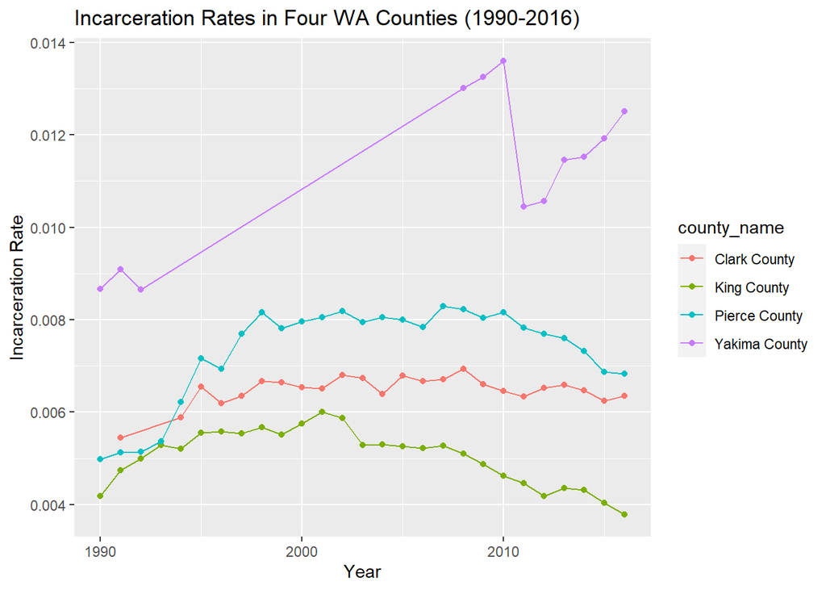

This chart reflects the total incarceration rate to the total population of each specific county in Washington State throughout the years 1990 and 2016. In creating a ratio of those incarcerated to the total population in each county every year, we get a better understanding of the incarceration rates of each county. In this chart, I chose four counties, three random counties and one chosen deliberately, King County, since we live there. Through this chart we see that the incarceration rate in Yakima County is much larger than the other 3 counties. What this means is that the amount of people incarcerated compared to the amount of people who live there is high in comparison to the other three counties shown in this chart. In King County, it seems that its incarceration rate is much lower than the other three. This is very interesting to see as King County has the highest population in Washington State, so the fact that it has a lower incarceration rate compared to the population amount along with the other three counties reflects a lot onto King County as a whole. It means that compared to the amount of people who live there, not many get incarcerated. Another trend that I see is that incarceration rates for almost all of the counties except for Yakima have seem to be dropping. The reason this chart was designed this way is so the reader can look at each counties incarceration rates over the years as well as compare it to the other counties.

### Variable Comparison Chart

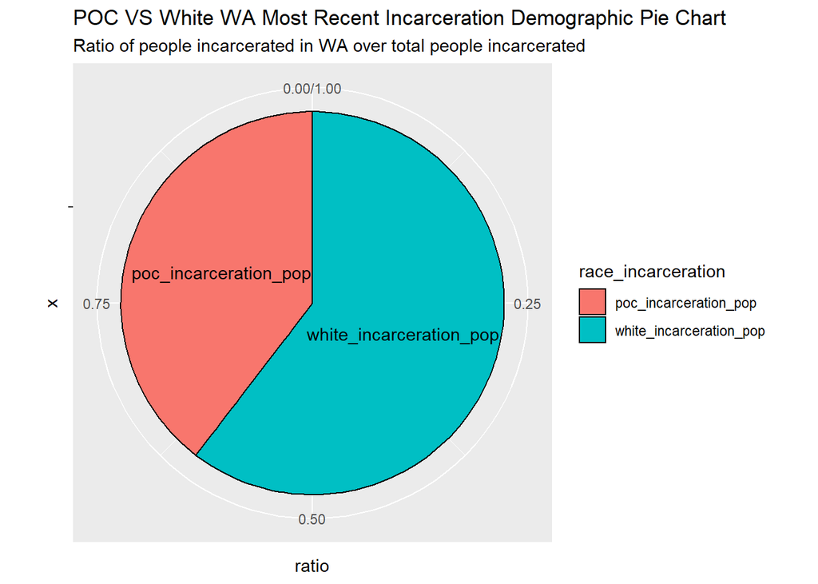

### Map

[figure not shown]

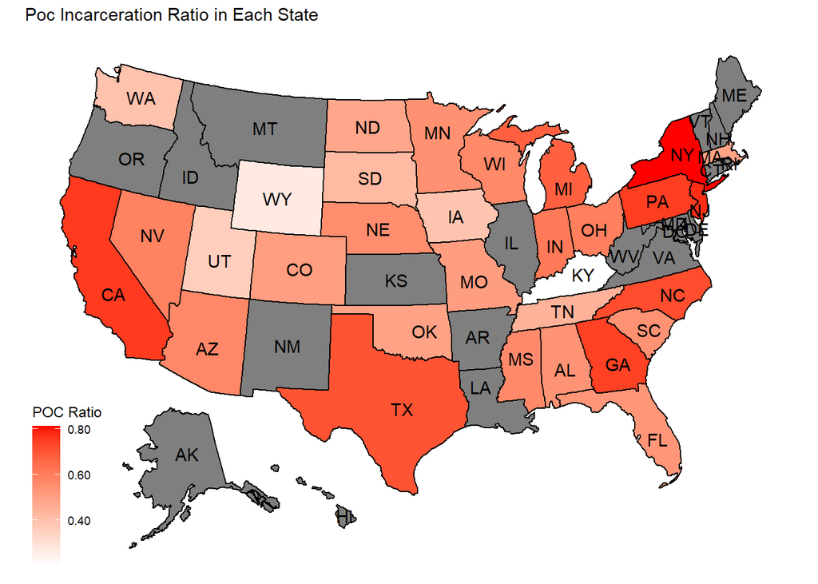

These last two maps show the ratio of a certain racial demographic who are incarcerated over the total incarceration population of the state. The first map looks at white incarceration population over total incarceration population, while the second map looks at POC incarceration population over total incarceration population. The reason for creating such maps is to allow the reader to visually see which states target POC, and in turn, have a higher ratio of the POC community incarcerated compared to the total amount of people incarcerated. With these maps, we can use the different shades of red to make different assumptions. The darker the red, the higher the ratio of incarceration is for that demographic. The lighter the red, the lower the ratio. It is also important to mention that the grey is an indicator that there is no data for that state. When wrangling the data, I dropped all rows with NA’s which most likely dropped those states’ data.

While we can use this map to look at which states are targeting specific racial groups, we can also use this map to show us which states are about even with their incarceration rates. States like CO, OK, ND, NV, etc., where the shade of red is right in between the lightest and darkest red act as an indicator that the ratio is about even, which in turn implies that that state does not target either the POC or White population.